# Simulating data with cellmig

Simo Kitanovski (simo.kitanovski@uni-due.de)

10 Juni 2025

# Contents

```r
library(cellmig)
library(ggplot2)
library(ggforce)
library(patchwork)
library(skimr)
ggplot2::theme_set(new = theme_bw(base_size = 10))
```

# 1 Motivation

In this vignette, we demonstrate the capabilities of cellmig to generate cell velocity data through two case studies:

1. Simulation from a `partially generative` model (user-specified parameters with some random components)
2. Simulation from a `fully generative` model (all parameters randomly generated)

# 2 Data simulation from **partially generative** model

We generate data using an experimental design specified in the `control` list:

```r
control <- list(
  N_biorep = 4,     # Biological replicates (independent plates)
  N_techrep = 3,    # Technical replicates (wells per plate)
  N_cell = 30,      # Cells per well
  delta = c(0, -0.4, -0.2, -0.1, 0, 0.1, 0.2, 0.4),  # Treatment effects
  sigma_bio = 0.2,  # Biological variability
  sigma_tech = 0.05,# Technical variability
  offset = 1,       # Systematic offset (explain usage if relevant)
  prior_alpha_p_M = 1.7,    # Mean for plate effects
  prior_alpha_p_SD = 0.5,   # SD for plate effects
  prior_kappa_mu_M = 1.7,   # Mean for kappa location
  prior_kappa_mu_SD = 0.5,  # SD for kappa location
  prior_kappa_sigma_M = 0,  # Mean for kappa scale
  prior_kappa_sigma_SD = 0.3# SD for kappa scale
)
```

Experimental design parameters:

- 4 biological replicates (independent experimental plates, $p = \{1,2,3,4\}$)
- 3 technical replicates per biological replicate (wells per plate)
- 30 cells per well
- 8 treatment groups ($t = \{1,...,8\}$) with fixed effects $\delta_t$ = [0, -0.4, -0.2, -0.1, 0, 0.1, 0.2, 0.4]
- Biological replicate variability: $\sigma_\text{bio}}$ = 0.2
- Technical replicate variability: $\sigma_\text{tech}}$ = 0.05

## 2.1 Model specification

### 2.1.1 Setting $\alpha_p$

I assume that there are strong plate-specific batch effects, which is what we typically observe in real experiments. To generate such effects, we draw random values for the parameter $\alpha_p$

$\alpha_p \sim \text{Normal}(1.7, 0.5)$

where $\alpha_p$ represents the plate-specific offset. The mean (defined by parameter `prior_alpha_p_M`=1.7) and standard deviation (defined by parameter `prior_alpha_p_SD`=0.5) of the normal distribution are defined in `control`.

### 2.1.2 Setting $\kappa_w$

The velocities in each well are gamma distributed, and the gamma distribution is defined by a rate and shape parameter. The shape parameter for well $w$, $\kappa_w$, controls the form or skewness of the distribution and, to some extent, the variability in the data.

We simulate the values of $\log(\kappa_w)$ by drawing randomly from a normal distribution with mean ($\mu_{\kappa}$) and standard deviation (${\sigma}_{\kappa}$). The values of $\mu_{\kappa}$ and ${\sigma}_{\kappa}$ can either be fixed to point values, or be drawn from two normal distributions whose means and standard deviations are described by the inputs `prior_kappa_mu_M`, `prior_kappa_sigma_M`, `prior_kappa_mu_SD`, and `prior_kappa_sigma_SD`. To fix the values of $\mu_{\kappa}$ and ${\sigma}_{\kappa}$ to point estimates set the scales to small values (e.g., set in `control` `prior_kappa_mu_SD`=0.01 and `prior_kappa_sigma_SD`).

### 2.1.3 Defining the offset

To do batch effect correction across plates we have to select one of treatment as a reference. We do this by setting the parameter `offset` = $x$ in the `control`, where $x \in t$. In this example `offset=1`.

## 2.2 Generates dataframe with simulated velocities

```r
# set seed for reproducible results
set.seed(seed = 1252)
# simulate data
y_p <- gen_partial(control = control)
```

```r
# see data structure
str(y_p$y)
```

```
FALSE 'data.frame': 2880 obs. of  6 variables:
FALSE  $ v       : num  4.74 2.29 3.02 3.8 2.67 ...
FALSE  $ well    : num  1 1 1 1 1 1 1 1 1 1 ...
FALSE  $ plate   : int  1 1 1 1 1 1 1 1 1 1 ...
FALSE  $ group   : int  1 1 1 1 1 1 1 1 1 1 ...
FALSE  $ compound: int  1 1 1 1 1 1 1 1 1 1 ...
FALSE  $ dose    : chr  "X" "X" "X" "X" ...
```

We can visualize data data as a scatterplot with cells as dots

- y-axis = velocity
- x-axis = treatment group
- color = plate identifier

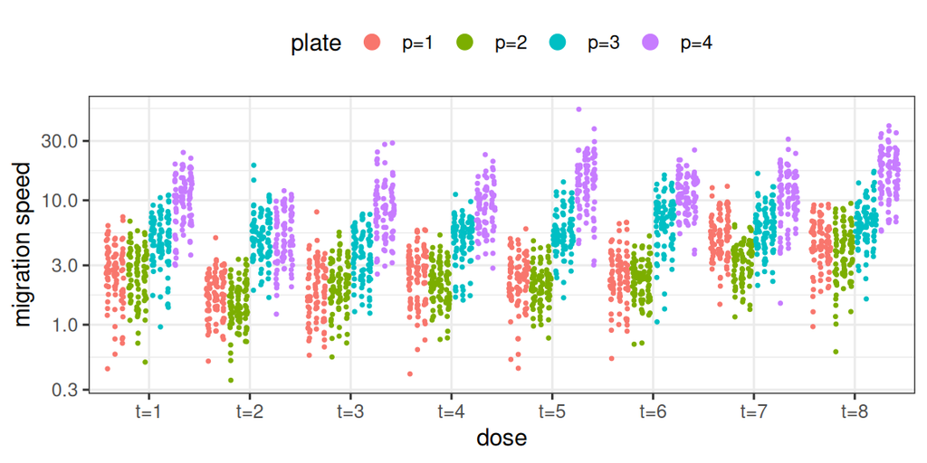

```r
ggplot(data = y_p$y)+
  geom_sina(aes(x = paste0("t=", group), col = paste0("p=", plate),
                y = v, group = well), size = 0.5)+
  theme_bw()+
  theme(legend.position = "top",
        strip.text.x = element_text(margin = margin(0.03,0,0.03,0, "cm")))+
  xlab(label = "dose")+
  ylab(label = "migration speed")+
  guides(color = guide_legend(override.aes = list(size = 3)))+
  scale_color_discrete(name = "plate")+
  scale_y_log10()
```

… or we can just show the plate-specific means (below). Notice, the systematic batch effects between plates.

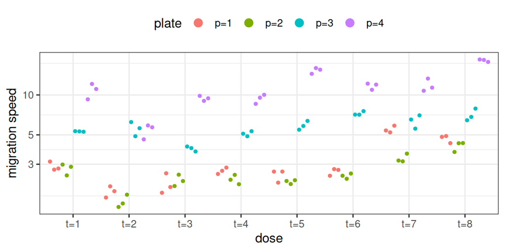

```r
ggplot(data = aggregate(v~well+group+plate, data = y_p$y, FUN = mean))+
  geom_sina(aes(x = paste0("t=", group), col = paste0("p=", plate),
                y = v, group = well), size = 1)+
  theme_bw()+
  theme(legend.position = "top",
        strip.text.x = element_text(margin = margin(0.03,0,0.03,0, "cm")))+
  xlab(label = "dose")+
  ylab(label = "migration speed")+
  guides(color = guide_legend(override.aes = list(size = 3)))+
  scale_y_log10()+
  scale_color_discrete(name = "plate")
```

### 2.2.1 Generated data can be **analyzed** with `cellmig`

```r
sim_data <- y_p$y

# format simulated data to be used as input in cellmig
sim_data$well <- as.character(sim_data$well)
sim_data$compound <- as.character(sim_data$compound)
sim_data$plate <- as.character(sim_data$plate)
sim_data$offset <- 0
sim_data$offset[sim_data$group=="1"] <- 1


osd <- cellmig(x = sim_data,
               control = list(mcmc_warmup = 300,
                              mcmc_steps = 1000,
                              mcmc_chains = 3,
                              mcmc_cores = 3,
                              mcmc_algorithm = "NUTS",
                              adapt_delta = 0.8,
                              max_treedepth = 10))
```

### 2.2.2 Compare simulated vs inferred parameters

Let’s compare inferred (black) vs originally simulated (red) $\alpha_p$

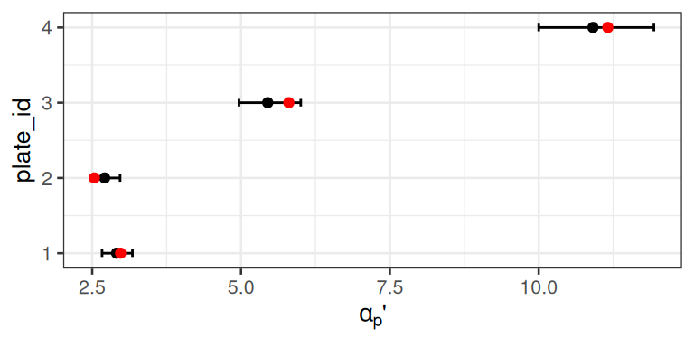

```r
ggplot(data = osd$posteriors$alpha_p)+
  geom_point(aes(y = plate_id, x = exp(mean)))+
  geom_errorbarh(aes(y = plate_id, x = exp(mean), xmin = exp(X2.5.),
                     xmax = exp(X97.5.)), height = 0.1)+
  geom_point(data = data.frame(v = exp(y_p$par$alpha_p), plate = 1:4),
             aes(y = plate, x = v), col = "red")+
  scale_y_continuous(breaks = 1:4)+
  xlab(label = expression(alpha[p]*"'"))
```

… and also $\delta_t$

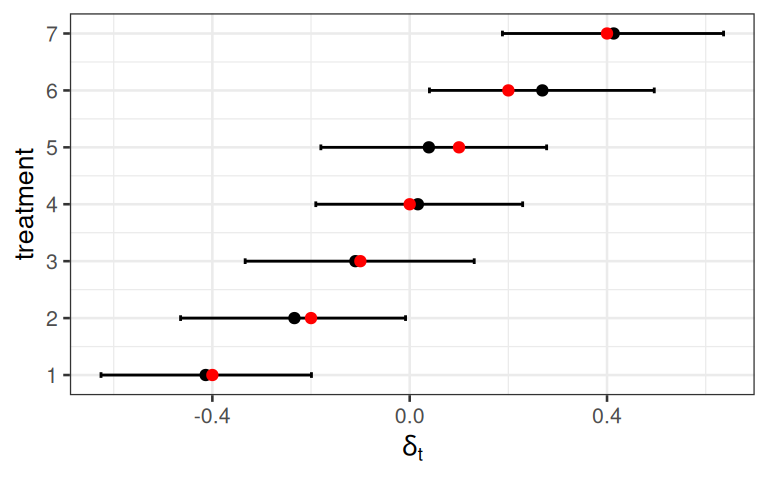

```r
ggplot(data = osd$posteriors$mu_group)+
  geom_point(aes(y = group_id, x = mean))+
  geom_errorbarh(aes(y = group_id, x = mean, xmin = X2.5., xmax = X97.5.), height = 0.1)+
  geom_point(data = data.frame(delta = c(-0.4, -0.2, -0.1, 0, 0.1, 0.2, 0.4), group_id = 1:7),
             aes(y = group_id, x = delta), col = "red")+
  xlab(label = expression(delta[t]))+
  ylab(label = "treatment")+
  scale_y_continuous(breaks = 1:8)
```

# 3 Data simulation from **fully generative** model

We can also use `cellmig` to generate cell velocities from the prior distributions of the parameters $\rightarrow$ data from prior predictive distribution

In this scenario, the parameters, such as $\delta_t$, will not be fixed to point values but rather generated from their priors.

## 3.1 Model specification

```r
control <- list(N_biorep = 4,
                N_techrep = 3,
                N_cell = 30,
                N_group = 8,
                prior_alpha_p_M = 1.7,
                prior_alpha_p_SD = 1.0,
                prior_kappa_mu_M = 1.7,
                prior_kappa_mu_SD = 1.0,
                prior_kappa_sigma_M = 0,
                prior_kappa_sigma_SD = 1.0,
                prior_sigma_bio_M = 0.0,
                prior_sigma_bio_SD = 1.0,
                prior_sigma_tech_M = 0.0,
                prior_sigma_tech_SD = 1.0,
                prior_mu_group_M = 0.0,
                prior_mu_group_SD = 1.0)
```

```r
# generate data
y_f <- gen_full(control = control)
```

```
FALSE Chain 1:
FALSE Chain 1:  Elapsed Time: 0 seconds (Warm-up)
FALSE Chain 1:                0.002 seconds (Sampling)
FALSE Chain 1:                0.002 seconds (Total)
FALSE Chain 1:
```

The generate data has a similar structure as before:

```r
str(y_f)
```

```
FALSE List of 2
FALSE  $ y      :'data.frame':  2880 obs. of  8 variables:
FALSE   ..$ i       : int [1:2880] 1 2 3 4 5 6 7 8 9 10 ...
FALSE   ..$ v       : num [1:2880] 0.313 12.967 26.546 0.219 18.798 ...
FALSE   ..$ well    : chr [1:2880] "1" "1" "1" "1" ...
FALSE   ..$ plate   : chr [1:2880] "1" "1" "1" "1" ...
FALSE   ..$ group   : chr [1:2880] "1" "1" "1" "1" ...
FALSE   ..$ compound: chr [1:2880] "1" "1" "1" "1" ...
FALSE   ..$ dose    : chr [1:2880] "X" "X" "X" "X" ...
FALSE   ..$ trep_id : int [1:2880] 1 1 1 1 1 1 1 1 1 1 ...
FALSE  $ control:List of 19
FALSE   ..$ N_biorep            : num 4
FALSE   ..$ N_techrep           : num 3
FALSE   ..$ N_cell              : num 30
FALSE   ..$ N_group             : num 8
FALSE   ..$ prior_alpha_p_M     : num 1.7
FALSE   ..$ prior_alpha_p_SD    : num 1
FALSE   ..$ prior_kappa_mu_M    : num 1.7
FALSE   ..$ prior_kappa_mu_SD   : num 1
FALSE   ..$ prior_kappa_sigma_M : num 0
FALSE   ..$ prior_kappa_sigma_SD: num 1
FALSE   ..$ prior_sigma_bio_M   : num 0
FALSE   ..$ prior_sigma_bio_SD  : num 1
FALSE   ..$ prior_sigma_tech_M  : num 0
FALSE   ..$ prior_sigma_tech_SD : num 1
FALSE   ..$ prior_mu_group_M    : num 0
FALSE   ..$ prior_mu_group_SD   : num 1
FALSE   ..$ N_plate             : num 4
FALSE   ..$ N_well_reps         : num 3
FALSE   ..$ offset              : num 1
```

## 3.2 Compare density of velocities from partially vs. fully generative models

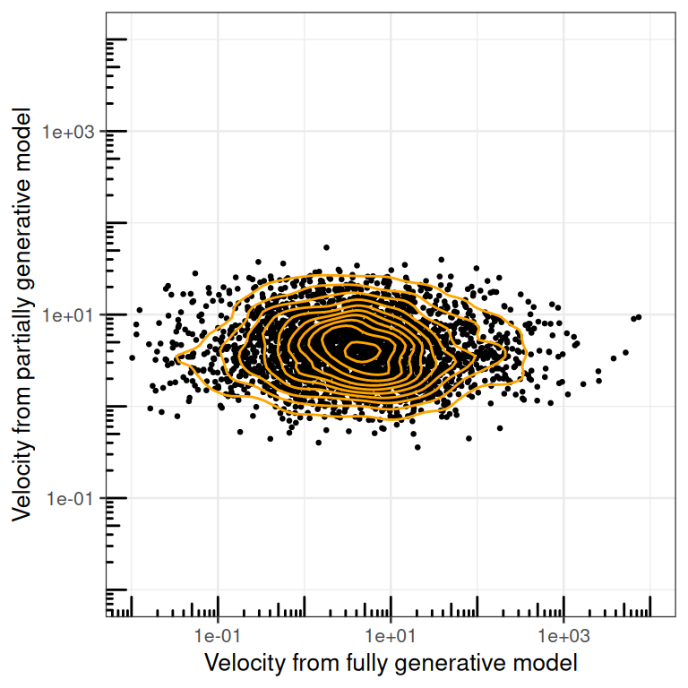

[output not shown]

```r
w <- data.frame(v_f = y_f$y$v, v_p = y_p$y$v)
 ggplot(data = w)+
    geom_point(aes(x = v_f, y = v_p), size = 0.5)+
    geom_density_2d(aes(x = v_f, y = v_p), col = "orange")+
    scale_x_log10(name = "Velocity from fully generative model", limits = c(0.01, 10^4))+
    scale_y_log10(name = "Velocity from partially generative model", limits = c(0.01, 10^4))+
    annotation_logticks(base = 10, sides = "lb")+
    theme_bw(base_size = 10)
```